# Clustering SCPCL000822 and SCPCL000824

Ally Hawkins

2024-08-01

This notebook does some initial exploration of clustering in two libraries from `SCPCP000015`: `SCPCL000822` and `SCPCL000824`.

- Louvain clusters are calculated using a range of parameters specifying nearest neighbors (5, 10, 15, 20, 25, 30, 35, and 40).
- Metrics are then calculated to evaluate clustering results across all parameters:
  - Silhouette width
  - Cluster purity
  - Cluster stability

The clusters are then compared to the results from running `SingleR` in the `aucell-singler-annotation.sh` workflow. We then look at marker gene expression across the clusters and assign each cluster to a cell type.

## Setup

```r
suppressPackageStartupMessages({
  # load required packages
  library(SingleCellExperiment)
  library(ggplot2)
})

# Set default ggplot theme
theme_set(
  theme_bw()
)

# set seed
set.seed(2024)
```

```r
# The base path for the OpenScPCA repository, found by its (hidden) .git directory
repository_base <- rprojroot::find_root(rprojroot::is_git_root)

# The current data directory, found within the repository base directory
data_dir <- file.path(repository_base, "data", "current", "SCPCP000015")

# The path to this module
module_base <- file.path(repository_base, "analyses", "cell-type-ewings")

# path to marker genes file
marker_genes_file <- file.path(module_base, "references", "visser-all-marker-genes.tsv")
```

```r
# source in helper functions for make_jaccard_matrix() and jaccard()
jaccard_functions <- file.path(module_base, "scripts", "utils", "jaccard-functions.R")
source(jaccard_functions)

# source in helper functions: plot_gene_heatmap() and plot_cnv_heatmap()
# create_classification_df() and create_marker_gene_df()
validation_functions <- file.path(module_base, "scripts", "utils", "tumor-validation-helpers.R")
source(validation_functions)
```

## Define functions

```r
# get clusters for a specified value of k
get_clusters <- function(pcs, k) {
  clusters <- bluster::clusterRows(
    pcs,
    bluster::NNGraphParam(
      k = k,
      type = "jaccard",
      cluster.fun = "louvain"
    )
  )

  return(clusters)
}

# define a function to perform clustersweep and get clusters across multiple values of k
cluster_sweep <- function(sce) {
  # first perform clustering across parameters
  cluster_results <- bluster::clusterSweep(reducedDim(sce, "PCA"),
    bluster::NNGraphParam(),
    k = as.integer(seq(5, 40, 5)),
    cluster.fun = "louvain",
    type = "jaccard"
  )

  # turn results into a data frame
  cluster_df <- cluster_results$clusters |>
    as.data.frame() |>
    # add barcode column
    dplyr::mutate(barcodes = colnames(sce)) |>
    # combine all cluster results into one column
    tidyr::pivot_longer(
      cols = ends_with("jaccard"),
      names_to = "params",
      values_to = "cluster"
    ) |>
    # separate out parameters, nn, function, and type into their own columns
    dplyr::mutate(
      nn_param = stringr::word(params, 1, sep = "_") |>
        stringr::str_replace("k.", "k_"),
      cluster_fun = stringr::word(params, 2, sep = "_") |>
        stringr::str_remove("cluster.fun."),
      cluster_type = stringr::word(params, -1, sep = "_") |>
        stringr::str_remove("type.")
    ) |>
    # remove combined params column
    dplyr::select(-params)

  return(cluster_df)
}
```

```r
# cluster statistics functions
# get silhouette width and cluster purity for each cluster
# calculates values across all nn_param options used to determine clustering
# all_cluster_results must have nn_param column
get_cluster_stats <- function(sce,
                              id,
                              all_cluster_results) {
  pcs <- reducedDim(sce, "PCA")

  # split clustering results by library id and param used
  split_clusters <- all_cluster_results |>
    dplyr::filter(library_id == id) |>
    split(all_cluster_results$nn_param)

  # for each nn_param get cluster width and purity
  all_stats_df <- split_clusters |>
    purrr::map(\(df){
      sil_df <- bluster::approxSilhouette(pcs, df$cluster) |>
        as.data.frame() |>
        tibble::rownames_to_column("barcodes")

      purity_df <- bluster::neighborPurity(pcs, df$cluster) |>
        as.data.frame() |>
        tibble::rownames_to_column("barcodes")

      # join into one data frame to return
      stats_df <- sil_df |>
        dplyr::left_join(purity_df, by = "barcodes")

      return(stats_df)
    }) |>
    dplyr::bind_rows(.id = "nn_param")

  return(all_stats_df)
}

# calculate cluster stability for a single set of clusters using ari
# bootstrap and get ari for clusters compared to sampled clusters
# re-clusters and gets ari across 20 iterations
get_ari <- function(pcs,
                    clusters,
                    k) {
  ari <- c()
  for (iter in 1:20) {
    # sample cells with replacement
    sample_cells <- sample(nrow(pcs), nrow(pcs), replace = TRUE)
    resampled_pca <- pcs[sample_cells, , drop = FALSE]

    # perform clustering on sampled cells
    resampled_clusters <- get_clusters(resampled_pca, k)

    # calculate ARI between new clustering and original clustering
    ari[iter] <- pdfCluster::adj.rand.index(resampled_clusters, clusters[sample_cells])
  }

  ari_df <- data.frame(
    ari = ari,
    k_value = k
  )
}

# get cluster stability for each nn_param cluster results are available for
# calculated the ari between original clusters and shuffled clusters 20 times
get_cluster_stability <- function(sce,
                                  id,
                                  all_cluster_results) {
  pcs <- reducedDim(sce, "PCA")

  # split clustering results by library id and param used
  cluster_df_list <- all_cluster_results |>
    dplyr::filter(library_id == id) |>
    split(all_cluster_results$nn_param)

  # for each parameter, get ari values
  cluster_stability_df <- cluster_df_list |>
    purrr::imap(\(df, k_value){
      # make sure k is numeric and remove extra k_
      k <- stringr::str_remove(k_value, "k_") |>
        as.numeric()

      get_ari(pcs, df$cluster, k)
    }) |>
    dplyr::bind_rows()

  return(cluster_stability_df)
}
```

```r
# heatmap comparing cluster assignments to SingleR labels
cluster_celltype_heatmap <- function(cluster_classification_df,
                                     id) {
  # get a jaccard mtx for each cluster param
  jaccard_df_list <- cluster_classification_df |>
    dplyr::filter(library_id == id) |>
    split(cluster_classification_df$nn_param) |>
    purrr::map(\(df) {
      make_jaccard_matrix(
        df,
        "cluster",
        "singler_lumped"
      )
    })

  # turn into heatmap list
  make_heatmap_list(jaccard_df_list, column_title = glue::glue("{id}-clusters"), legend_match = "k_5")
}


# Density plot looking at marker gene expression across all clusters
# each panel is from a different marker gene list
# each row shows marker gene expression for that cluster
plot_marker_genes <- function(cluster_classification_df,
                              k_value,
                              id) {
  # pick clustering to use and select those columns
  final_clusters_df <- cluster_classification_df |>
    dplyr::filter(nn_param == k_value) |>
    dplyr::filter(library_id == id)

  # grab columns that contain marker gene sums
  marker_gene_columns <- colnames(final_clusters_df)[which(endsWith(colnames(final_clusters_df), "_sum"))]

  # create individual density plots and combine into one
  marker_gene_columns |>
    purrr::map(\(column){
      plot_density(
        final_clusters_df,
        column,
        "cluster"
      )
    }) |>
    patchwork::wrap_plots(ncol = 1) + patchwork::plot_annotation(glue::glue("{id}-{k_value}-clusters"))
}
```

## Prepare data

```r
# sample and library ids
sample_ids <- c("SCPCS000490", "SCPCS000492")
library_ids <- c("SCPCL000822", "SCPCL000824")

# define input sce files
sce_file_names <- glue::glue("{library_ids}_processed.rds")
sce_files <- file.path(data_dir, sample_ids, sce_file_names) |>
  purrr::set_names(library_ids)

# define classification files
singler_results_dir <- file.path(module_base, "results", "aucell_singler_annotation")
classification_file_names <- glue::glue("{library_ids}_singler-classifications.tsv")
classification_files <- file.path(singler_results_dir, sample_ids, classification_file_names) |>
  purrr::set_names(library_ids)

# define output files
cluster_results_dir <- file.path(module_base, "results", "clustering", sample_ids)
cluster_results_dir |>
  purrr::map(fs::dir_create)
```

```
## [[1]]
## /Users/allyhawkins/Documents/ALSF/forked_repos/OpenScPCA-analysis/analyses/cell-type-ewings/results/clustering/SCPCS000490
##
## [[2]]
## /Users/allyhawkins/Documents/ALSF/forked_repos/OpenScPCA-analysis/analyses/cell-type-ewings/results/clustering/SCPCS000492
```

```r
cluster_file_names <- glue::glue("{library_ids}_cluster-results.tsv")
cluster_output_files <- file.path(cluster_results_dir, cluster_file_names) |>
  purrr::set_names(library_ids)
```

```r
# read in both SCEs
sce_list <- sce_files |>
  purrr::map(readr::read_rds)

# read in classification data frame with SingleR results and combine into one
classification_df <- classification_files |>
  purrr::map(readr::read_tsv) |>
  dplyr::bind_rows(.id = "library_id")
# read in marker genes table
marker_genes_df <- readr::read_tsv(marker_genes_file, show_col_types = FALSE) |>
  # account for genes being from multiple sources
  dplyr::select(cell_type, ensembl_gene_id, gene_symbol) |>
  dplyr::distinct()

# get list of all cell types found
cell_types <- unique(marker_genes_df$cell_type)

# get the sum of expression of all genes for each cell type
gene_exp_df <- sce_list |>
  purrr::map(\(sce) {
    cell_types |>
      purrr::map(\(type){
        calculate_sum_markers(marker_genes_df, sce, type)
      }) |>
      purrr::reduce(dplyr::inner_join, by = "barcodes")
  }) |>
  dplyr::bind_rows(.id = "library_id")

# join sum expression columns with classification df
classification_df <- classification_df |>
  dplyr::left_join(gene_exp_df, by = c("barcodes", "library_id"))
```

## Clustering

Below we perform Louvain, Jaccard clustering, varying `k`. The minimum `k` is 5 and the maximum `k` is 40 with a step size of 5.

```r
# perform clustering across k = 5-40 with increments of 5
all_cluster_results <- sce_list |>
  purrr::map(cluster_sweep) |>
  dplyr::bind_rows(.id = "library_id")
```

```r
# get umap embeddings and combine into a data frame with cluster assignments
umap_df <- sce_list |>
  purrr::map(\(sce){
    df <- sce |>
      scuttle::makePerCellDF(use.dimred = "UMAP") |>
      # replace UMAP.1 with UMAP1 and get rid of excess columns
      dplyr::select(barcodes, UMAP1 = UMAP.1, UMAP2 = UMAP.2)
  }) |>
  dplyr::bind_rows(.id = "library_id") |>
  dplyr::left_join(all_cluster_results, by = c("library_id", "barcodes"))
```

Below we visualize the cluster assignments using each parameter on a UMAP. This isn’t particularly useful because of clusters, but it can be helpful to see any values of K that may have obvious over or under clustering.

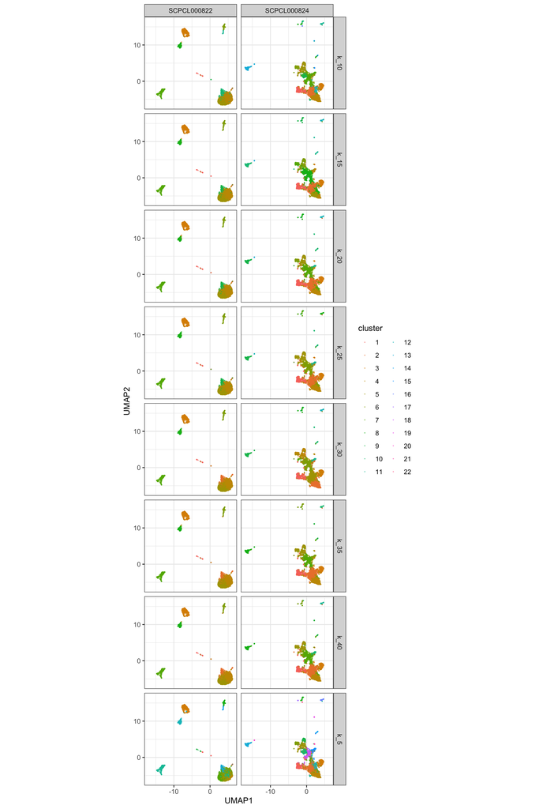

```r
# look at clustering results across all params
ggplot(umap_df, aes(x = UMAP1, y = UMAP2, color = cluster)) +
  geom_point(alpha = 0.5, size = 0.1) +
  facet_grid(
    cols = vars(library_id),
    rows = vars(nn_param)
  ) +
  theme(aspect.ratio = 1)
```

### Clustering statistics

Below we calculate a series of statistics:

- Average silhouette width: This metric evaluates cluster separation. Cells with large positive silhouette widths are closer to other cells in the same cluster than to cells in different clusters.
- Average cluster purity: This metric also evaluates cluster separation and tells us the proportion of neighboring cells that are assigned to the same cluster. Higher purity values indicate that clusters are well separated.
- Cluster stability: This evaluates how stable the clustering is to input data. Higher values of cluster stability indicate more reproducible clusters.

```r
# get a combined stats dataframe with purity and width for all clusters
all_stats_df <- sce_list |>
  purrr::imap(\(sce, library_id){
    get_cluster_stats(sce, library_id, all_cluster_results)
  }) |>
  dplyr::bind_rows(.id = "library_id")
```

```r
# summarize the silhouette width and purity for each nn_param used
summary_stats_df <- all_stats_df |>
  dplyr::group_by(library_id, nn_param) |>
  dplyr::summarise(
    mean_width = mean(width),
    mean_purity = mean(purity)
  ) |>
  dplyr::mutate(
    # make sure the order is correct
    nn_param = forcats::fct_relevel(nn_param, "k_5", after = 0)
  )
```

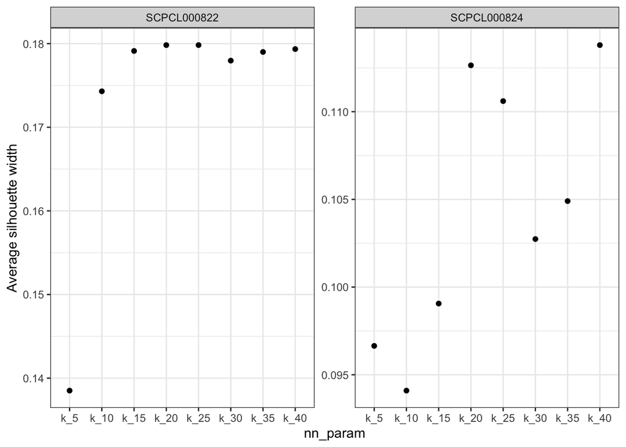

```r
# silhouette width for different params
ggplot(summary_stats_df, aes(x = nn_param, y = mean_width)) +
  geom_point() +
  facet_wrap(vars(library_id),
    scales = "free_y"
  ) +
  labs(y = "Average silhouette width")
```

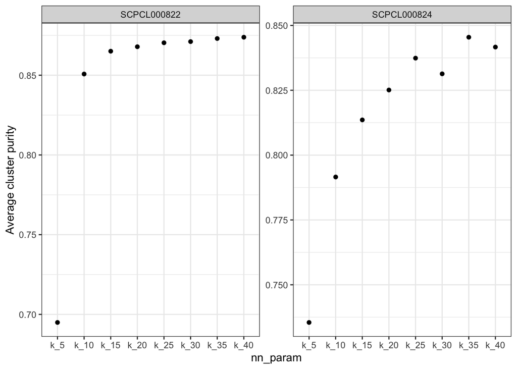

```r
# cluster purity for different params
ggplot(summary_stats_df, aes(x = nn_param, y = mean_purity)) +
  geom_point() +
  facet_wrap(vars(library_id),
    scales = "free_y"
  ) +
  labs(y = "Average cluster purity")
```

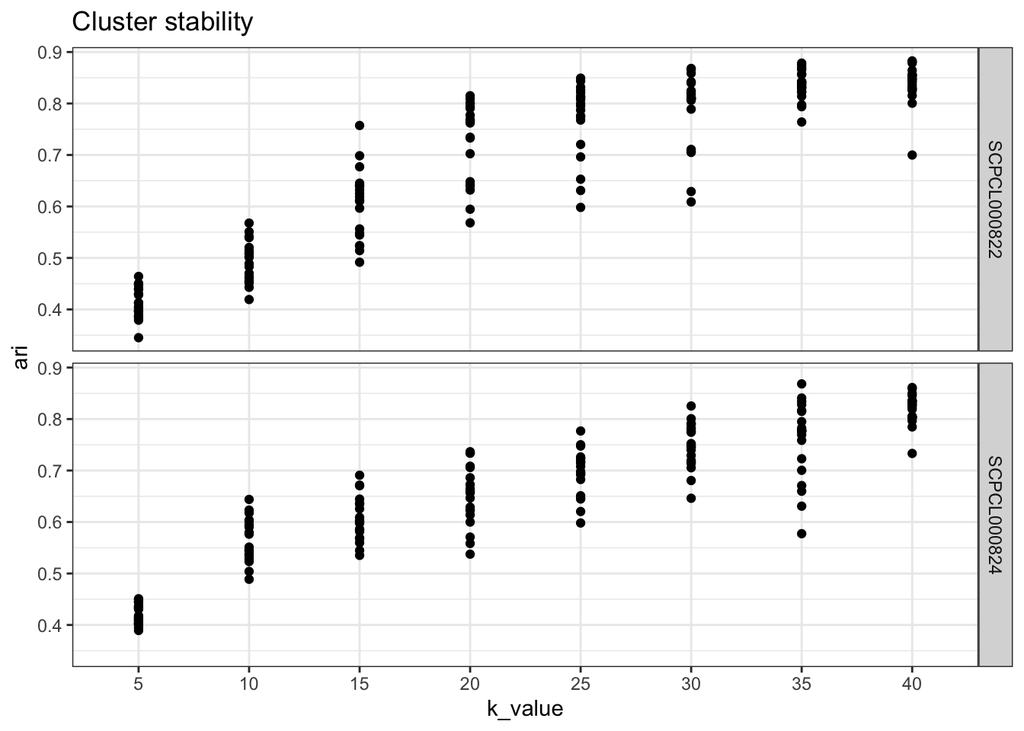

```r
# calculate cluster stability
stability_df <- sce_list |>
  purrr::imap(\(sce, id){
    get_cluster_stability(sce, id, all_cluster_results)
  }) |>
  dplyr::bind_rows(.id = "library_id") |>
  dplyr::mutate(
    k_value = as.factor(k_value),
    # make sure that k = 5 comes first
    k_value = forcats::fct_relevel(k_value, "5", after = 0)
  )

# plot stability across all values of k
ggplot(stability_df, aes(x = k_value, y = ari)) +
  geom_point() +
  facet_grid(rows = vars(library_id)) +
  labs(title = "Cluster stability")
```

Here we see that cluster stability increases as k increases for both libraries. We see a plateau start to appear around k = 20 and k = 25.

## Compare clusters to cell types from `SingleR`

Now we will compare the clustering results to the cell type assignments obtained from `SingleR` in the `aucell-singler-annotation.sh` workflow. To compare results we will calculate the Jaccard similarity index between clusters and cell types. We expect that good clustering will line up with the cell type assignments so that there is ~ 1 cell type per cluster.

For the plots, we will only display the top 7 cell types and all other cells will be lumped together into `All remaining cell types`.

```r
cluster_classification_df <- all_cluster_results |>
  # add in classifications from singler
  dplyr::left_join(classification_df, by = c("library_id", "barcodes")) |>
  dplyr::mutate(
    # first grab anything that is tumor and label it tumor
    # NA should be unknown
    singler_annotation = dplyr::case_when(
      stringr::str_detect(singler_annotation, "tumor") ~ "tumor",
      is.na(singler_annotation) ~ "unknown", # make sure to separate out unknown labels
      .default = singler_annotation
    ) |>
      forcats::fct_relevel("tumor", after = 0),
    # get the top cell types for plotting later
    singler_lumped = singler_annotation |>
      forcats::fct_lump_n(7, other_level = "All remaining cell types", ties.method = "first") |>
      forcats::fct_infreq() |>
      forcats::fct_relevel("All remaining cell types", after = Inf)
  )
```

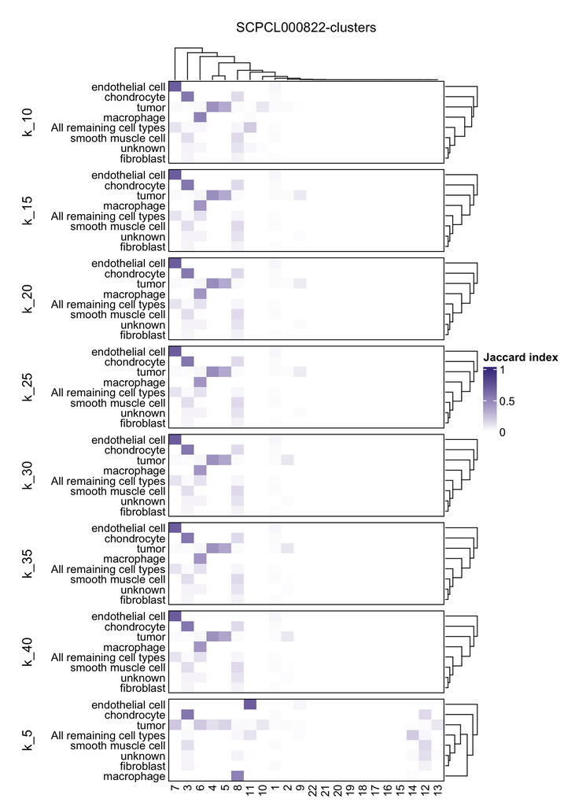

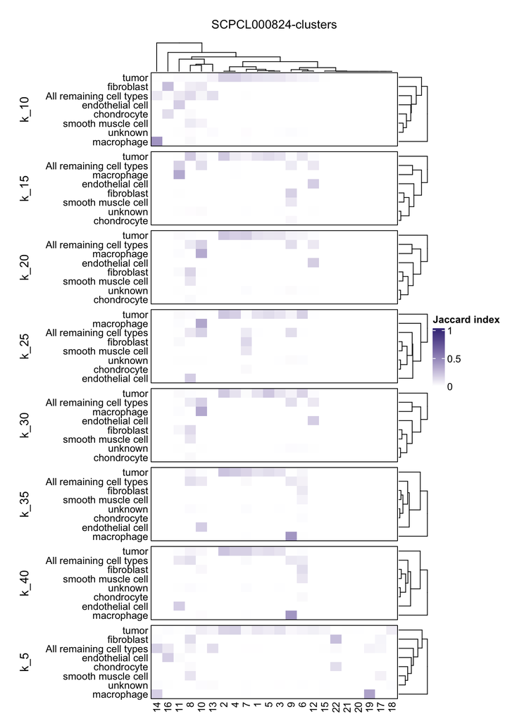

```r
# get heatmap for each library showing cluster assignments vs. singler assignments
names(sce_list) |>
  purrr::map(\(id){
    cluster_celltype_heatmap(
      cluster_classification_df,
      id
    )
  })
```

From these plots, it’s obvious that K = 5 is over clustering and cell types are spread across a lot of clusters. However, for the other values of K, there doesn’t seem to be any striking difference that are obvious by eye.

## Marker gene expression across clusters

We will also look at the expression of marker genes across each cluster. In these plots, each row shows the distribution of the specified marker genes in that cluster. Each panel is labeled with the marker gene expression being plotted.

Based on the above results, we will only show these plots for a value of K = 25.

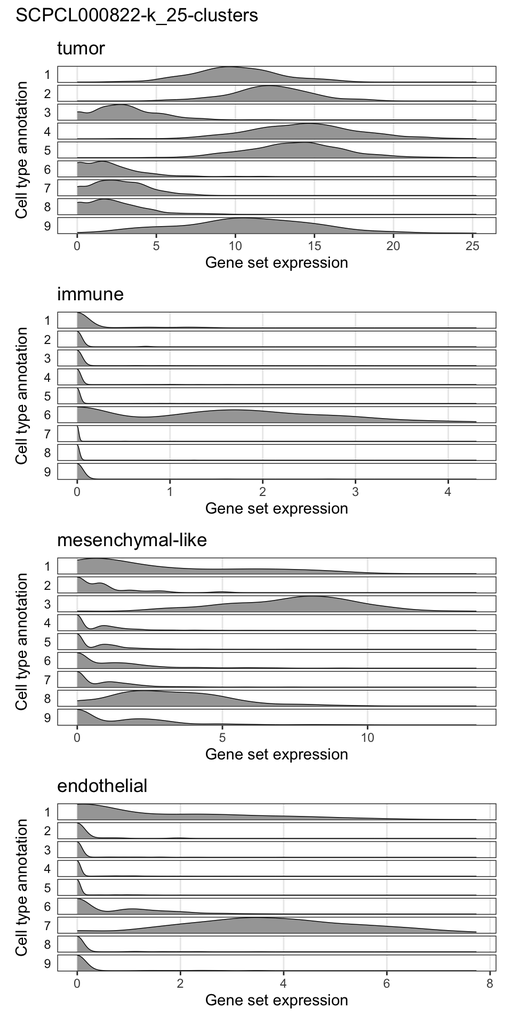

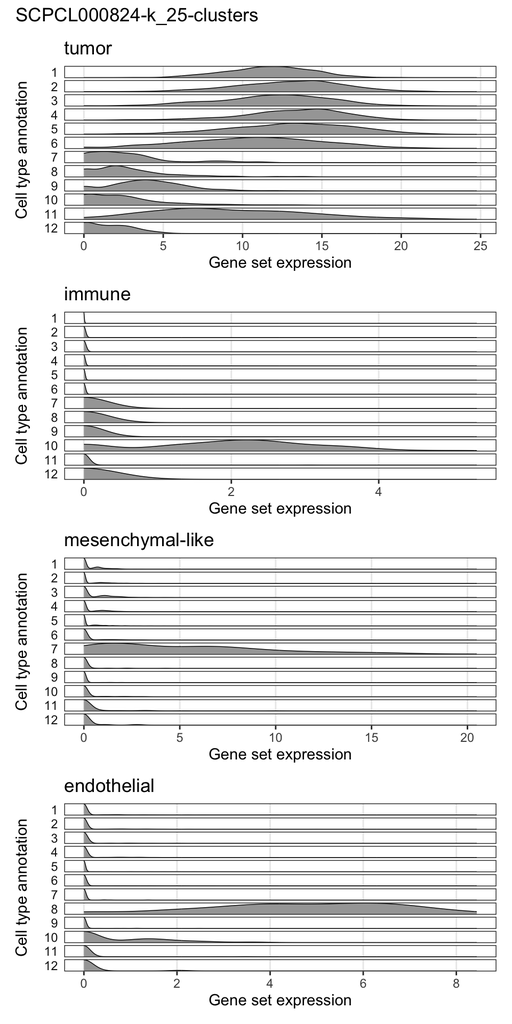

```r
# plot to look at marker gene expression for all cell types across all clusters
# choose k=25 based on previous stats
names(sce_list) |>
  purrr::map(\(id) {
    plot_marker_genes(cluster_classification_df,
      k_value = "k_25",
      id
    )
  })
```

For both samples we see very clear separation between clusters that express tumor marker genes and each of the normal cell marker genes.

## Assign cell types to clusters

Finally, we will assign cell types to all cells in a cluster based on a cluster having high expression of a set of marker genes.

```r
# get umap embeddings for plotting later
umap_df <- umap_df |>
  dplyr::select(library_id, barcodes, UMAP1, UMAP2) |>
  dplyr::distinct()

# assign clusters based on marker gene expression and cell types that are prominent in that cluster
# use the jaccard matrices to help guide assignments
cluster_umap_df <- cluster_classification_df |>
  dplyr::left_join(umap_df, by = c("library_id", "barcodes")) |>
  dplyr::filter(nn_param == "k_25") |>
  dplyr::mutate(
    cluster_celltype = dplyr::case_when(
      library_id == "SCPCL000822" & cluster %in% c(1, 2, 4, 5, 9) ~ "tumor",
      library_id == "SCPCL000822" & cluster == 7 ~ "endothelial cell",
      # cluster 3 has predominantly chondrocytes and has MSC marker gene expression
      library_id == "SCPCL000822" & cluster == 3 ~ "chondrocyte",
      # clusters with high "immune" marker gene expression are macrophage
      library_id == "SCPCL000822" & cluster == 6 ~ "macrophage",
      # cluster 8 has high MSC marker gene expression and a mix of MSC like cell types
      library_id == "SCPCL000822" & cluster == 8 ~ "mesenchymal-like cell",
      library_id == "SCPCL000824" & cluster %in% c(1, 2, 3, 4, 5, 6, 11) ~ "tumor",
      library_id == "SCPCL000824" & cluster == 8 ~ "endothelial cell",
      # cluster 10 has high immune markers and is mostly macrohpages
      library_id == "SCPCL000824" & cluster == 10 ~ "macrophage",
      # cluster 7 has high MSC marker gene expression and a mix of MSC like cell types
      library_id == "SCPCL000824" & cluster == 7 ~ "mesenchymal-like cell",
      # if they didn't have high expression of any markers, we label them as unknown
      .default = "unknown"
    ),
    # make tumor first
    cluster_celltype = forcats::fct_relevel(cluster_celltype, "tumor", after = 0)
  )
```

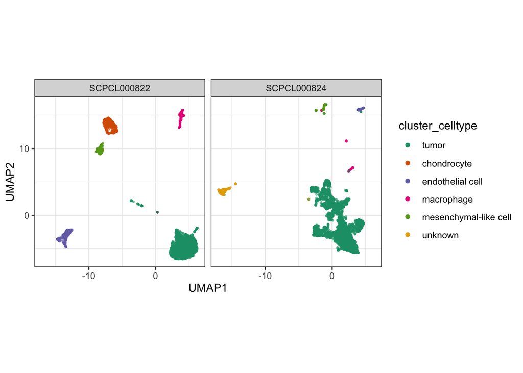

```r
# look at cell type assignments on the UMAP
ggplot(cluster_umap_df, aes(x = UMAP1, y = UMAP2, color = cluster_celltype)) +
  geom_point(alpha = 0.5, size = 0.5) +
  facet_grid(cols = vars(library_id)) +
  theme(aspect.ratio = 1) +
  guides(color = guide_legend(override.aes = list(alpha = 1, size = 1.5))) +
  scale_color_brewer(palette = "Dark2")
```

We can also validate that these cells do in fact have higher expression of the marker genes as compared to other cells by plotting the marker gene expression on UMAPs.

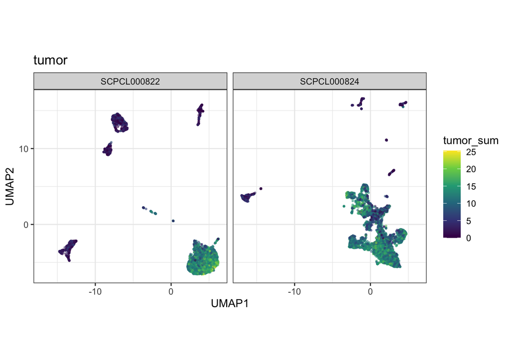

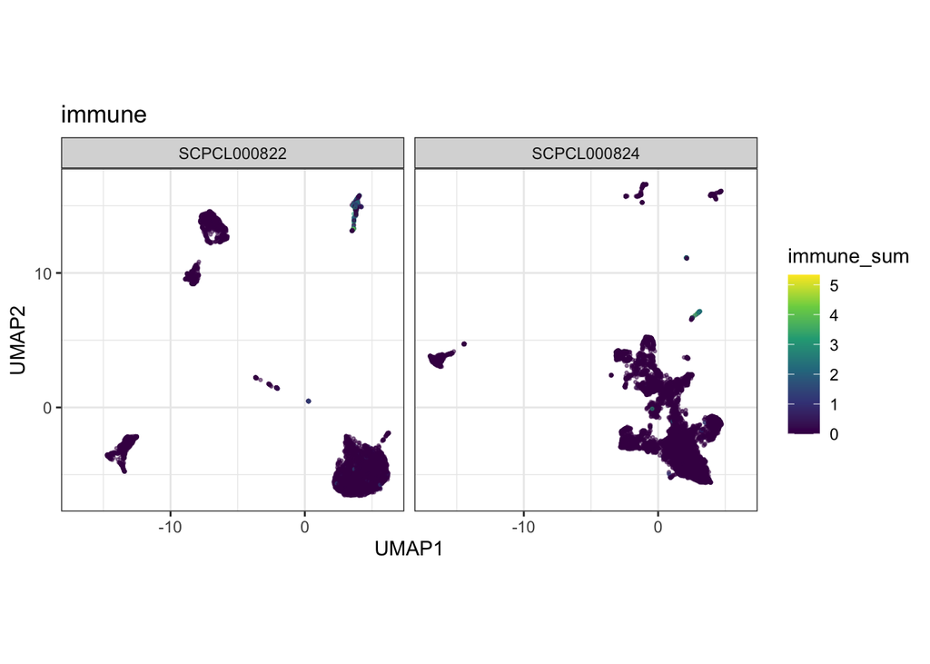

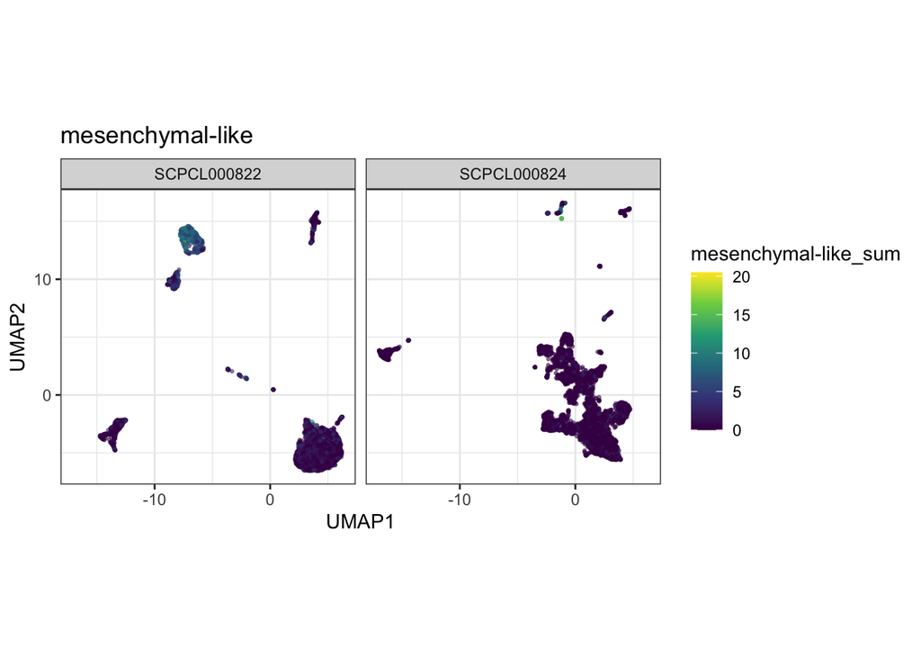

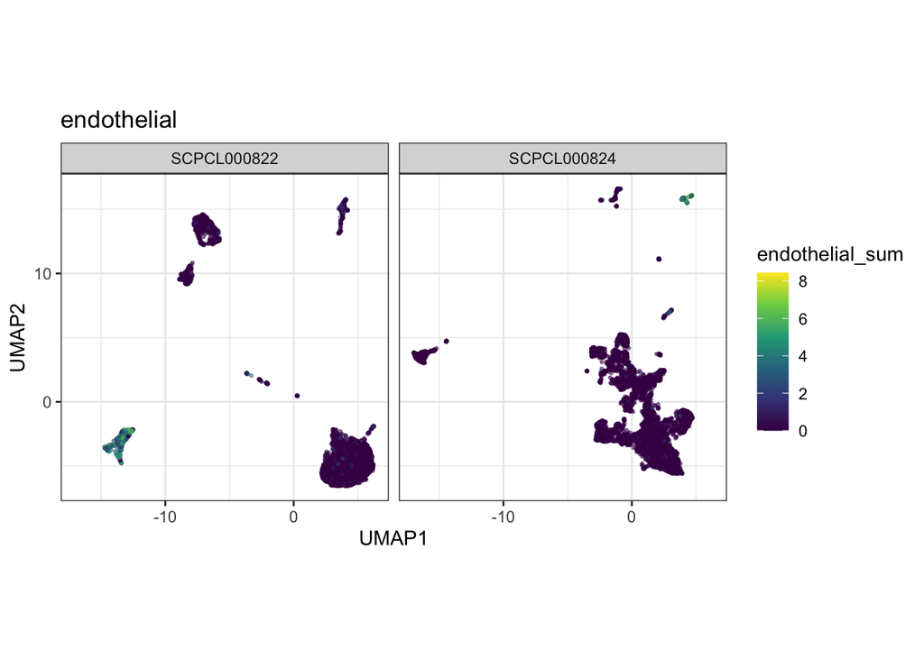

```r
# grab columns that contain marker gene sums
marker_gene_columns <- colnames(cluster_umap_df)[which(endsWith(colnames(cluster_umap_df), "_sum"))]

# create individual density plots and combine into one
marker_gene_columns |>
  purrr::map(\(column){
    genelist_name <- stringr::str_remove(column, "_sum")

    ggplot(cluster_umap_df, aes(x = UMAP1, y = UMAP2, color = !!sym(column))) +
      geom_point(alpha = 0.5, size = 0.5) +
      facet_grid(cols = vars(library_id)) +
      theme(aspect.ratio = 1) +
      scale_color_viridis_c() +
      labs(
        title = genelist_name
      )
  })
```

## Save clustering and annotations

Here we will save the assigned clusters and cell type annotations for each library. Each file will have the following columns:

- `barcodes`: Unique cell barcode
- `cluster`: Assigned cluster
- `cluster_celltype`: Cell type assigned based on clustering and marker gene expression
- `nn_param`: Number of nearest neighbors used as a parameter for clustering
- `singler_ontology`: Cell ontology identifier for assigned cell type by `SingleR`
- `singler_annotation`: Cell type assigned by `SingleR`
- `consensus_celltype`: Consensus between cluster assignments and `SingleR` assignments for tumor cells. Here any cell in a cluster with tumor cells will be labeled with `tumor` and all other cells will be labeled with the `SingleR` annotation.

```r
cluster_output_files |>
  purrr::iwalk(\(file, id){
    cluster_umap_df |>
      dplyr::filter(library_id == id) |>
      dplyr::select(barcodes, cluster, cluster_celltype, nn_param, singler_ontology, singler_annotation) |>
      dplyr::mutate(consensus_celltype = dplyr::if_else(cluster_celltype == "tumor", "tumor", singler_annotation)) |>
      readr::write_tsv(file)
  })
```